# Sports Bra Preferences

Taylor Hixson, Jye-Jiun Liu, Michael Jiang, Diego Camones

10/27/2023

# Conjoint analysis

## Step 1. Development of product bundles to evaluate

### Create combinations

```r
# Load the 'conjoint' library for conducting conjoint analysis
library(conjoint)

# 1. Create all theoretically possible combinations
# This code snippet generates a data frame called 'experiment' that contains all possible combinations
# of attributes for your product or service. These attributes include Flavor, Size, Superfoods, Filling, and Price.

experiment <- expand.grid(
  Style = c("Racerback","Cross-back","Single shoulder", "Halter neck"),
  Color = c("Red", "Black", "White", "Blue"),
  Adjustrable_straps = c("Non-adjustable straps","Adjustable Straps"),
  Padding = c("No padding", "Removable padding", "Padding"),
  Price = c("21.99","24.99","28.99") # in Euro
)

# Display the 'experiment' data frame to see the generated combinations
experiment
```

[output not shown]

```r
# Save the data in Excel
# Uncomment and modify this line to save the 'experiment' data frame to an Excel file if needed.
# write_excel_csv(experiment)
```

### Reduced decision: Orthogoinal

```r
library(conjoint)
# 1. Orthogonal Design
# Generate an orthogonal design using the 'caFactorialDesign' function
ortho.design <- caFactorialDesign(data = experiment,
                                  type = "orthogonal",
                                  seed = 123)

# Print the orthogonal design
ortho.design
```

```
##               Style Color    Adjustrable_straps           Padding Price
## 10       Cross-back White Non-adjustable straps        No padding 21.99
## 29        Racerback  Blue     Adjustable Straps        No padding 21.99
## 44      Halter neck White Non-adjustable straps Removable padding 21.99
## 63  Single shoulder  Blue     Adjustable Straps Removable padding 21.99
## 69        Racerback Black Non-adjustable straps           Padding 21.99
## 71  Single shoulder Black Non-adjustable straps           Padding 21.99
## 82       Cross-back   Red     Adjustable Straps           Padding 21.99
## 84      Halter neck   Red     Adjustable Straps           Padding 21.99
## 120     Halter neck Black     Adjustable Straps        No padding 24.99
## 129       Racerback   Red Non-adjustable straps Removable padding 24.99
## 174      Cross-back  Blue Non-adjustable straps           Padding 24.99
## 187 Single shoulder White     Adjustable Straps           Padding 24.99
## 195 Single shoulder   Red Non-adjustable straps        No padding 28.99
## 246      Cross-back Black     Adjustable Straps Removable padding 28.99
## 272     Halter neck  Blue Non-adjustable straps           Padding 28.99
## 281       Racerback White     Adjustable Straps           Padding 28.99
```

Quality check

```r
# Check the quality of the orthogonal design using a correlation matrix
cor(caEncodedDesign(ortho.design))
```

```
##                    Style Color Adjustrable_straps Padding Price
## Style                  1     0                  0       0     0
## Color                  0     1                  0       0     0
## Adjustrable_straps     0     0                  1       0     0
## Padding                0     0                  0       1     0
## Price                  0     0                  0       0     1
```

### Reduced decision: Factorial, 20

```r
# 2. Fractional Design
# Generate a fractional design using the 'caFactorialDesign' function
# Here, we specify 'cards' to control the size of the fractional design.
frac20.design <- caFactorialDesign(data = experiment,
                                 type = "fractional",
                                 cards = 20,
                                 seed = 123)

# Encoding variable levels of the fractional design
profiles <- caEncodedDesign(design = frac20.design)

# Print the encoded profiles of the fractional design
print(profiles)
```

```
##     Style Color Adjustrable_straps Padding Price
## 9       1     3                  1       1     1
## 31      3     4                  2       1     1
## 39      3     2                  1       2     1
## 52      4     1                  2       2     1
## 68      4     1                  1       3     1
## 86      2     2                  2       3     1
## 99      3     1                  1       1     2
## 114     2     1                  2       1     2
## 133     1     2                  1       2     2
## 156     4     3                  2       2     2
## 157     1     4                  2       2     2
## 170     2     3                  1       3     2
## 176     4     4                  1       3     2
## 183     3     2                  2       3     2
## 200     4     2                  1       1     3
## 216     4     2                  2       1     3
## 227     3     1                  1       2     3
## 238     2     4                  1       2     3
## 273     1     1                  2       3     3
## 283     3     3                  2       3     3
```

#### Quality check: Fractional design

Step 1

```r
# Print the fractional design
frac20.design
```

```
##               Style Color    Adjustrable_straps           Padding Price
## 9         Racerback White Non-adjustable straps        No padding 21.99
## 31  Single shoulder  Blue     Adjustable Straps        No padding 21.99
## 39  Single shoulder Black Non-adjustable straps Removable padding 21.99
## 52      Halter neck   Red     Adjustable Straps Removable padding 21.99
## 68      Halter neck   Red Non-adjustable straps           Padding 21.99
## 86       Cross-back Black     Adjustable Straps           Padding 21.99
## 99  Single shoulder   Red Non-adjustable straps        No padding 24.99
## 114      Cross-back   Red     Adjustable Straps        No padding 24.99
## 133       Racerback Black Non-adjustable straps Removable padding 24.99
## 156     Halter neck White     Adjustable Straps Removable padding 24.99
## 157       Racerback  Blue     Adjustable Straps Removable padding 24.99
## 170      Cross-back White Non-adjustable straps           Padding 24.99
## 176     Halter neck  Blue Non-adjustable straps           Padding 24.99
## 183 Single shoulder Black     Adjustable Straps           Padding 24.99
## 200     Halter neck Black Non-adjustable straps        No padding 28.99
## 216     Halter neck Black     Adjustable Straps        No padding 28.99
## 227 Single shoulder   Red Non-adjustable straps Removable padding 28.99
## 238      Cross-back  Blue Non-adjustable straps Removable padding 28.99
## 273       Racerback   Red     Adjustable Straps           Padding 28.99
## 283 Single shoulder White     Adjustable Straps           Padding 28.99
```

Step 2

```r
# Check the quality of the fractional design using a correlation matrix
cor(profiles)
```

```
##                          Style       Color Adjustrable_straps     Padding Price
## Style               1.00000000 -0.13223140         0.00000000 -0.03954171     0
## Color              -0.13223140  1.00000000         0.00000000  0.03954171     0
## Adjustrable_straps  0.00000000  0.00000000         1.00000000  0.06213698     0
## Padding            -0.03954171  0.03954171         0.06213698  1.00000000     0
## Price               0.00000000  0.00000000         0.00000000  0.00000000     1
```

Low correlation so this is good

Save in excel so can build survey instrument

```r
## Save in Excel
# write_excel_csv(frac.design, "frac.design.csv")
```

### Reduced decision: Factorial, 12

```r
# 2. Fractional Design
# Generate a fractional design using the 'caFactorialDesign' function
# Here, we specify 'cards' to control the size of the fractional design.
frac12.design <- caFactorialDesign(data = experiment,
                                 type = "fractional",
                                 cards = 12,
                                 seed = 123)

# Encoding variable levels of the fractional design
profiles12 <- caEncodedDesign(design = frac12.design)

# Print the encoded profiles of the fractional design
print(profiles12)
```

```
##     Style Color Adjustrable_straps Padding Price
## 9       1     3                  1       1     1
## 32      4     4                  2       1     1
## 38      2     2                  1       2     1
## 51      3     1                  2       2     1
## 103     3     2                  1       1     2
## 157     1     4                  2       2     2
## 164     4     1                  1       3     2
## 186     2     3                  2       3     2
## 210     2     1                  2       1     3
## 252     4     3                  2       2     3
## 271     3     4                  1       3     3
## 277     1     2                  2       3     3
```

#### Quality check: Fractional design

```r
# Check the quality of the fractional design using a correlation matrix
cor(profiles12)
```

```
##                          Style       Color Adjustrable_straps Padding     Price
## Style               1.00000000 -0.06666667        -0.07559289   0.000 0.0000000
## Color              -0.06666667  1.00000000         0.07559289   0.000 0.0000000
## Adjustrable_straps -0.07559289  0.07559289         1.00000000   0.000 0.2070197
## Padding             0.00000000  0.00000000         0.00000000   1.000 0.3750000
## Price               0.00000000  0.00000000         0.20701967   0.375 1.0000000
```

```r
## Save in Excel
write_excel_csv(frac12.design, "/Users/taylorhixson/OneDrive - ESMT Berlin/ESMT/QMM/3_4/frac12.design.csv")
```

### Reduced decision: Factorial, 15

```r
# 2. Fractional Design
# Generate a fractional design using the 'caFactorialDesign' function
# Here, we specify 'cards' to control the size of the fractional design.
frac15.design <- caFactorialDesign(data = experiment,
                                 type = "fractional",
                                 cards = 15,
                                 seed = 123)

# Encoding variable levels of the fractional design
profiles15 <- caEncodedDesign(design = frac15.design)

# Print the encoded profiles of the fractional design
print(profiles15)
```

```
##     Style Color Adjustrable_straps Padding Price
## 9       1     3                  1       1     1
## 32      4     4                  2       1     1
## 43      3     3                  1       2     1
## 50      2     1                  2       2     1
## 72      4     2                  1       3     1
## 100     4     1                  1       1     2
## 143     3     4                  1       2     2
## 149     1     2                  2       2     2
## 186     2     3                  2       3     2
## 206     2     4                  1       1     3
## 215     3     2                  2       1     3
## 230     2     2                  1       2     3
## 252     4     3                  2       2     3
## 269     1     4                  1       3     3
## 275     3     1                  2       3     3
```

#### Quality check: Fractional design

```r
# Check the quality of the fractional design using a correlation matrix
cor(profiles15)
```

```
##                          Style       Color Adjustrable_straps     Padding
## Style               1.00000000 -0.13636364         0.09869275 -0.11165160
## Color              -0.13636364  1.00000000        -0.27140507 -0.11165160
## Adjustrable_straps  0.09869275 -0.27140507         1.00000000  0.08080749
## Padding            -0.11165160 -0.11165160         0.08080749  1.00000000
## Price              -0.11534197  0.02883549         0.08347839  0.10793087
##                          Price
## Style              -0.11534197
## Color               0.02883549
## Adjustrable_straps  0.08347839
## Padding             0.10793087
## Price               1.00000000
```

15 is a nice spot between 12 and 20, but should decide ask Vlada for her opinion if it is that much better than 12

```r
## Save in Excel
write_excel_csv(frac15.design, "/Users/taylorhixson/OneDrive - ESMT Berlin/ESMT/QMM/3_4/frac15.design.csv")
```

```r
print(frac15.design)
```

```
##               Style Color    Adjustrable_straps           Padding Price
## 9         Racerback White Non-adjustable straps        No padding 21.99
## 32      Halter neck  Blue     Adjustable Straps        No padding 21.99
## 43  Single shoulder White Non-adjustable straps Removable padding 21.99
## 50       Cross-back   Red     Adjustable Straps Removable padding 21.99
## 72      Halter neck Black Non-adjustable straps           Padding 21.99
## 100     Halter neck   Red Non-adjustable straps        No padding 24.99
## 143 Single shoulder  Blue Non-adjustable straps Removable padding 24.99
## 149       Racerback Black     Adjustable Straps Removable padding 24.99
## 186      Cross-back White     Adjustable Straps           Padding 24.99
## 206      Cross-back  Blue Non-adjustable straps        No padding 28.99
## 215 Single shoulder Black     Adjustable Straps        No padding 28.99
## 230      Cross-back Black Non-adjustable straps Removable padding 28.99
## 252     Halter neck White     Adjustable Straps Removable padding 28.99
## 269       Racerback  Blue Non-adjustable straps           Padding 28.99
## 275 Single shoulder   Red     Adjustable Straps           Padding 28.99
```

# Step 2. Build survey instrument

Look at output data from above and build survey instrument based on pairings.

[Preview the survey](https://esmt.az1.qualtrics.com/jfe/preview/previewId/cbf322b1-dff4-402f-9d9c-bcaeb35e7fa1/SV_3Po1QlmG9Do9Vsi?Q_CHL=preview&Q_SurveyVersionID=current)

# Step 3. Data analysis from collected survey data

Cleaned survey data

```r
data <- readxl::read_excel("/Users/taylorhixson/OneDrive - ESMT Berlin/ESMT/QMM/project/Sports Bra Preferences_November 7, 2023_15.16.xlsx", sheet = "data_num")
```

Data transferred by stimuli

```r
CAData <- readxl::read_excel("/Users/taylorhixson/OneDrive - ESMT Berlin/ESMT/QMM/project/Sports Bra Preferences_November 7, 2023_15.16.xlsx", sheet = "stimuli")
```

Social demographic data sheet

```r
SocDem <- readxl::read_excel("/Users/taylorhixson/OneDrive - ESMT Berlin/ESMT/QMM/project/Sports Bra Preferences_November 7, 2023_15.16.xlsx", sheet = "demographic")
```

```r
## Descriptive statistics
SocDem %>%
  count(Language)
```

```
## # A tibble: 2 × 2
##   Language     n
##   <chr>    <int>
## 1 English     29
## 2 Mandarin    20
```

```r
## Descriptive statistics
SocDem %>%
  count(Age)
```

```
## # A tibble: 4 × 2
##   Age       n
##   <chr> <int>
## 1 18-24     4
## 2 25-34    33
## 3 35-44     9
## 4 45-54     3
```

```r
## Descriptive statistics
## Transform from wide to long format: 44 respondents * 24 stimulus = 1056 rows

# Reshape the 'CAData' dataframe from wide to long format using the 'gather' function.
# This transformation collects responses from multiple columns into two new columns: 'Respondent' and 'Rating'.
CAData_long = CAData %>%
  gather(ResponseId, Rating, -c(Style, Color, Straps, Pads, Price, Stimuli)) %>%
  # Convert selected columns to factors for categorical data
  mutate(Style = as.factor(Style),
         Color = as.factor(Color),
         Straps = as.factor(Straps),
         Pads = as.factor(Pads),
         Price = as.factor(Price)) %>%
  # Merge the long-format data with demographic information from 'SocDem' based on the 'Respondent' column.
    left_join(SocDem, by = "ResponseId")




CAData_long
```

```
## # A tibble: 735 × 21
##    Stimuli Style       Color Straps Pads  Price ResponseId Rating Language Age
##      <dbl> <fct>       <fct> <fct>  <fct> <fct> <chr>       <dbl> <chr>    <chr>
##  1       1 Racerback   White Non-a… No p… 20.99 R_22rCHlQ…      4 English  25-34
##  2       2 Halter neck Blue  Adjus… No p… 20.99 R_22rCHlQ…      1 English  25-34
##  3       3 Single sho… White Non-a… Remo… 20.99 R_22rCHlQ…      1 English  25-34
##  4       4 Cross-back  Red   Adjus… Remo… 20.99 R_22rCHlQ…      1 English  25-34
##  5       5 Halter neck Black Non-a… Padd… 20.99 R_22rCHlQ…      1 English  25-34
##  6       6 Halter neck Red   Non-a… No p… 24.99 R_22rCHlQ…      1 English  25-34
##  7       7 Single sho… Blue  Non-a… Remo… 24.99 R_22rCHlQ…      1 English  25-34
##  8       8 Racerback   Black Adjus… Remo… 24.99 R_22rCHlQ…      9 English  25-34
##  9       9 Cross-back  White Adjus… Padd… 24.99 R_22rCHlQ…      5 English  25-34
## 10      10 Cross-back  Blue  Non-a… No p… 28.99 R_22rCHlQ…      1 English  25-34
## # ℹ 725 more rows
## # ℹ 11 more variables: `Exercise Frequency` <chr>, `Rarely or never` <lgl>,
## #   `1-2 times a week` <lgl>, `3-4 times a week` <lgl>, Daily <lgl>,
## #   `Low-intensity exercise (yoga, walking, golf, etc.` <lgl>,
## #   `High-intensity exercise (running, basketball, HIIT, etc.)` <lgl>,
## #   `Leisure and relaxation` <lgl>, `Daily wear` <lgl>,
## #   `I never wear sports bras` <lgl>, Situation_E <chr>
```

```r
str(CAData_long)
```

```
## tibble [735 × 21] (S3: tbl_df/tbl/data.frame)
##  $ Stimuli                                                  : num [1:735] 1 2 3 4 5 6 7 8 9 10 ...
##  $ Style                                                    : Factor w/ 4 levels "Cross-back","Halter neck",..: 3 2 4 1 2 2 4 3 1 1 ...
##  $ Color                                                    : Factor w/ 4 levels "Black","Blue",..: 4 2 4 3 1 3 2 1 4 2 ...
##  $ Straps                                                   : Factor w/ 2 levels "Adjustable straps",..: 2 1 2 1 2 2 2 1 1 2 ...
##  $ Pads                                                     : Factor w/ 3 levels "No padding","Padding",..: 1 1 3 3 2 1 3 3 2 1 ...
##  $ Price                                                    : Factor w/ 3 levels "20.99","24.99",..: 1 1 1 1 1 2 2 2 2 3 ...
##  $ ResponseId                                               : chr [1:735] "R_22rCHlQxb4Q7PHN" "R_22rCHlQxb4Q7PHN" "R_22rCHlQxb4Q7PHN" "R_22rCHlQxb4Q7PHN" ...
##  $ Rating                                                   : num [1:735] 4 1 1 1 1 1 1 9 5 1 ...
##  $ Language                                                 : chr [1:735] "English" "English" "English" "English" ...
##  $ Age                                                      : chr [1:735] "25-34" "25-34" "25-34" "25-34" ...
##  $ Exercise Frequency                                       : chr [1:735] "Rarely or never" "Rarely or never" "Rarely or never" "Rarely or never" ...
##  $ Rarely or never                                          : logi [1:735] TRUE TRUE TRUE TRUE TRUE TRUE ...
##  $ 1-2 times a week                                         : logi [1:735] FALSE FALSE FALSE FALSE FALSE FALSE ...
##  $ 3-4 times a week                                         : logi [1:735] FALSE FALSE FALSE FALSE FALSE FALSE ...
##  $ Daily                                                    : logi [1:735] FALSE FALSE FALSE FALSE FALSE FALSE ...
##  $ Low-intensity exercise (yoga, walking, golf, etc.        : logi [1:735] FALSE FALSE FALSE FALSE FALSE FALSE ...
##  $ High-intensity exercise (running, basketball, HIIT, etc.): logi [1:735] TRUE TRUE TRUE TRUE TRUE TRUE ...
##  $ Leisure and relaxation                                   : logi [1:735] FALSE FALSE FALSE FALSE FALSE FALSE ...
##  $ Daily wear                                               : logi [1:735] FALSE FALSE FALSE FALSE FALSE FALSE ...
##  $ I never wear sports bras                                 : logi [1:735] FALSE FALSE FALSE FALSE FALSE FALSE ...
##  $ Situation_E                                              : chr [1:735] "Low-intensity exercise (yoga, walking, golf, etc.),High-intensity exercise (running, basketball, HIIT, etc.)" "Low-intensity exercise (yoga, walking, golf, etc.),High-intensity exercise (running, basketball, HIIT, etc.)" "…
```

Summary statistics

```r
summary(CAData_long)
```

```
##     Stimuli               Style       Color                       Straps
##  Min.   : 1   Cross-back     :196   Black:196   Adjustable straps    :343
##  1st Qu.: 4   Halter neck    :196   Blue :196   Non-adjustable straps:392
##  Median : 8   Racerback      :147   Red  :147
##  Mean   : 8   Single shoulder:196   White:196
##  3rd Qu.:12
##  Max.   :15
##                 Pads       Price      ResponseId            Rating
##  No padding       :245   20.99:245   Length:735         Min.   :1.000
##  Padding          :196   24.99:196   Class :character   1st Qu.:2.000
##  Removable padding:294   28.99:294   Mode  :character   Median :4.000
##                                                         Mean   :4.205
##                                                         3rd Qu.:6.000
##                                                         Max.   :9.000
##    Language             Age            Exercise Frequency Rarely or never
##  Length:735         Length:735         Length:735         Mode :logical
##  Class :character   Class :character   Class :character   FALSE:555
##  Mode  :character   Mode  :character   Mode  :character   TRUE :180
##
##
##
##  1-2 times a week 3-4 times a week   Daily
##  Mode :logical    Mode :logical    Mode :logical
##  FALSE:480        FALSE:465        FALSE:705
##  TRUE :255        TRUE :270        TRUE :30
##
##
##
##  Low-intensity exercise (yoga, walking, golf, etc.
##  Mode :logical
##  FALSE:495
##  TRUE :240
##
##
##
##  High-intensity exercise (running, basketball, HIIT, etc.)
##  Mode :logical
##  FALSE:255
##  TRUE :480
##
##
##
##  Leisure and relaxation Daily wear      I never wear sports bras
##  Mode :logical          Mode :logical   Mode :logical
##  FALSE:570              FALSE:495       FALSE:720
##  TRUE :165              TRUE :240       TRUE :15
##
##
##
##  Situation_E
##  Length:735
##  Class :character
##  Mode  :character
##
##
##
```

Check for missing values because some things were weird

```r
colSums(is.na(CAData_long))
```

```
##                                                   Stimuli
##                                                         0
##                                                     Style
##                                                         0
##                                                     Color
##                                                         0
##                                                    Straps
##                                                         0
##                                                      Pads
##                                                         0
##                                                     Price
##                                                         0
##                                                ResponseId
##                                                         0
##                                                    Rating
##                                                         0
##                                                  Language
##                                                         0
##                                                       Age
##                                                         0
##                                        Exercise Frequency
##                                                         0
##                                           Rarely or never
##                                                         0
##                                          1-2 times a week
##                                                         0
##                                          3-4 times a week
##                                                         0
##                                                     Daily
##                                                         0
##         Low-intensity exercise (yoga, walking, golf, etc.
##                                                         0
## High-intensity exercise (running, basketball, HIIT, etc.)
##                                                         0
##                                    Leisure and relaxation
##                                                         0
##                                                Daily wear
##                                                         0
##                                  I never wear sports bras
##                                                         0
##                                               Situation_E
##                                                         0
```

## Calculate grand mean

```r
GrandMean = mean(CAData_long$Rating, na.rm = TRUE) # grand mean of the rating
GrandMean
```

```
## [1] 4.205442
```

## Average rating by attribute

### Price

```r
library(dplyr)

# average rating for price
CAData_long %>%
  group_by(Price) %>%
  summarise(mean_rating_price = mean(Rating, na.rm = TRUE))
```

```
## # A tibble: 3 × 2
##   Price mean_rating_price
##   <fct>             <dbl>
## 1 20.99              3.94
## 2 24.99              4.68
## 3 28.99              4.11
```

### Style

```r
library(dplyr)

# average rating for price
CAData_long %>%
  group_by(Style) %>%
  summarise(mean_rating_style = mean(Rating, na.rm = TRUE))
```

```
## # A tibble: 4 × 2
##   Style           mean_rating_style
##   <fct>                       <dbl>
## 1 Cross-back                   4.69
## 2 Halter neck                  3.58
## 3 Racerback                    5.22
## 4 Single shoulder              3.58
```

### Color

```r
library(dplyr)

# average rating for price
CAData_long %>%
  group_by(Color) %>%
  summarise(mean_rating_color = mean(Rating, na.rm = TRUE))
```

```
## # A tibble: 4 × 2
##   Color mean_rating_color
##   <fct>             <dbl>
## 1 Black              4.64
## 2 Blue               4.08
## 3 Red                3.80
## 4 White              4.19
```

### Straps

```r
library(dplyr)

# average rating for price
CAData_long %>%
  group_by(Straps) %>%
  summarise(mean_rating_straps = mean(Rating, na.rm = TRUE))
```

```
## # A tibble: 2 × 2
##   Straps                mean_rating_straps
##   <fct>                              <dbl>
## 1 Adjustable straps                   4.31
## 2 Non-adjustable straps               4.11
```

### Padding

```r
library(dplyr)

# average rating for price
CAData_long %>%
  group_by(Pads) %>%
  summarise(mean_rating_padding = mean(Rating, na.rm = TRUE))
```

```
## # A tibble: 3 × 2
##   Pads              mean_rating_padding
##   <fct>                           <dbl>
## 1 No padding                       3.77
## 2 Padding                          4.33
## 3 Removable padding                4.49
```

```
## No summary function supplied, defaulting to `mean_se()`
```

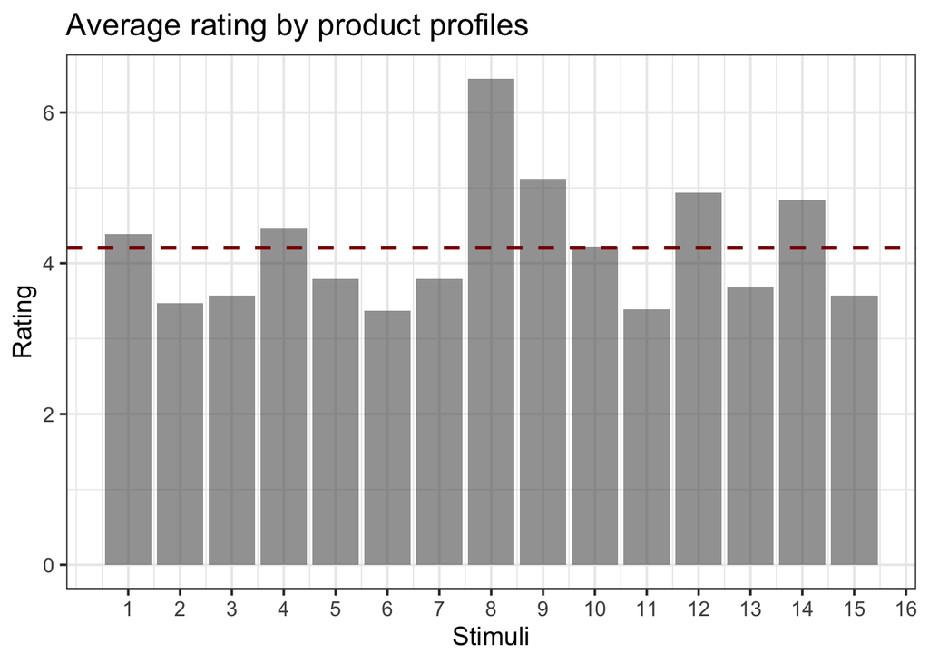

```r
# Calculate and summarize the average rating, standard deviation, minimum, and maximum rating by 'Stimuli'
average_rating_summary <- CAData_long %>%
  group_by(Stimuli) %>%
  summarise(
    m = mean(Rating, na.rm = TRUE),   # Calculate the mean rating
    sd = sd(Rating, na.rm = TRUE),     # Calculate the standard deviation of ratings
    min = min(Rating, na.rm = TRUE),   # Calculate the minimum rating
    max = max(Rating, na.rm = TRUE)    # Calculate the maximum rating
  )

# Load the 'ggplot2' library for data visualization
library(ggplot2)

# Create a bar plot showing the average rating by 'Stimuli'
ggplot(data = CAData_long, aes(x = Stimuli, y = Rating)) +
  geom_bar(stat = "summary", fun.y = "mean", alpha = 0.6) +  # Plot mean ratings as bars
  geom_hline(yintercept = GrandMean, linetype = 2, color = "darkred", size = 1) +  # Add a horizontal line for grand mean
  scale_x_continuous(breaks = seq(1, 24, 1)) +  # Adjust x-axis breaks for better readability
  theme_bw(base_size = 14) +  # Set the plot theme to black and white with a base font size of 14
  ggtitle("Average rating by product profiles")  # Set the plot title
```

## Part-worth: Estimate the preferences

```r
## Add dummy variables for attribute levels explicitly

CAData_long$Racerback <- ifelse(CAData_long$Style == "Racerback", 1, 0)
CAData_long$`Halter neck` <- ifelse(CAData_long$Style == "Halter neck", 1, 0)
CAData_long$`Single shoulder` <- ifelse(CAData_long$Style == "Single shoulder", 1, 0)
CAData_long$`Cross-back` <- ifelse(CAData_long$Style == "Cross-back", 1, 0)

CAData_long$White <- ifelse(CAData_long$Color == "White", 1, 0)
CAData_long$Blue <- ifelse(CAData_long$Color == "Blue", 1, 0)
CAData_long$Red <- ifelse(CAData_long$Color == "Red", 1, 0)
CAData_long$Black <- ifelse(CAData_long$Color == "Black", 1, 0)

CAData_long$`Non-adjustable straps` <- ifelse(CAData_long$Straps == "Non-adjustable straps", 1, 0)
CAData_long$`Adjustable straps` <- ifelse(CAData_long$Straps == "Adjustable straps", 1, 0)

CAData_long$`No padding` <- ifelse(CAData_long$Pads == "No padding", 1, 0)
CAData_long$`Removable padding` <- ifelse(CAData_long$Pads == "Removable padding", 1, 0)
CAData_long$`Padding` <- ifelse(CAData_long$Pads == "Padding", 1, 0)

CAData_long$`20.99` <- ifelse(CAData_long$Price == "20.99", 1, 0)
CAData_long$`24.99` <- ifelse(CAData_long$Price == "24.99", 1, 0)
CAData_long$`28.99` <- ifelse(CAData_long$Price == "28.99", 1, 0)

CAData_long
```

```
## # A tibble: 735 × 37
##    Stimuli Style       Color Straps Pads  Price ResponseId Rating Language Age
##      <dbl> <fct>       <fct> <fct>  <fct> <fct> <chr>       <dbl> <chr>    <chr>
##  1       1 Racerback   White Non-a… No p… 20.99 R_22rCHlQ…      4 English  25-34
##  2       2 Halter neck Blue  Adjus… No p… 20.99 R_22rCHlQ…      1 English  25-34
##  3       3 Single sho… White Non-a… Remo… 20.99 R_22rCHlQ…      1 English  25-34
##  4       4 Cross-back  Red   Adjus… Remo… 20.99 R_22rCHlQ…      1 English  25-34
##  5       5 Halter neck Black Non-a… Padd… 20.99 R_22rCHlQ…      1 English  25-34
##  6       6 Halter neck Red   Non-a… No p… 24.99 R_22rCHlQ…      1 English  25-34
##  7       7 Single sho… Blue  Non-a… Remo… 24.99 R_22rCHlQ…      1 English  25-34
##  8       8 Racerback   Black Adjus… Remo… 24.99 R_22rCHlQ…      9 English  25-34
##  9       9 Cross-back  White Adjus… Padd… 24.99 R_22rCHlQ…      5 English  25-34
## 10      10 Cross-back  Blue  Non-a… No p… 28.99 R_22rCHlQ…      1 English  25-34
## # ℹ 725 more rows
## # ℹ 27 more variables: `Exercise Frequency` <chr>, `Rarely or never` <lgl>,
## #   `1-2 times a week` <lgl>, `3-4 times a week` <lgl>, Daily <lgl>,
## #   `Low-intensity exercise (yoga, walking, golf, etc.` <lgl>,
## #   `High-intensity exercise (running, basketball, HIIT, etc.)` <lgl>,
## #   `Leisure and relaxation` <lgl>, `Daily wear` <lgl>,
## #   `I never wear sports bras` <lgl>, Situation_E <chr>, Racerback <dbl>, …
```

## Joint estimation

First, we evaluate the results of a joint estimation across all 49 respondents. The estimated utility parameters for the sample are shown below:

```r
model_jointly<- lm(Rating ~ Black
                       + Racerback
                       + `Non-adjustable straps`
                       + `No padding`
                       + `Cross-back`
                       + White
                       + Price,
                 data = CAData_long)
summary(model_jointly)
```

```
##
## Call:
## lm(formula = Rating ~ Black + Racerback + `Non-adjustable straps` +
##     `No padding` + `Cross-back` + White + Price, data = CAData_long)
##
## Residuals:
##     Min      1Q  Median      3Q     Max
## -5.1919 -1.8521 -0.5521  2.0706  5.7949
##
## Coefficients:
##                         Estimate Std. Error t value Pr(>|t|)
## (Intercept)              3.63149    0.25388  14.304  < 2e-16 ***
## Black                    0.47477    0.22479   2.112   0.0350 *
## Racerback                1.58322    0.24234   6.533 1.21e-10 ***
## `Non-adjustable straps` -0.25415    0.18517  -1.372   0.1703
## `No padding`            -0.42643    0.19902  -2.143   0.0325 *
## `Cross-back`             1.05773    0.21747   4.864 1.41e-06 ***
## White                    0.01801    0.22949   0.078   0.9375
## Price24.99               0.50243    0.24106   2.084   0.0375 *
## Price28.99              -0.03113    0.22114  -0.141   0.8881
## ---
## Signif. codes:  0 '***' 0.001 '**' 0.01 '*' 0.05 '.' 0.1 ' ' 1
##
## Residual standard error: 2.452 on 726 degrees of freedom
## Multiple R-squared:  0.09926,    Adjusted R-squared:  0.08933
## F-statistic:    10 on 8 and 726 DF,  p-value: 2.829e-13
```

```r
## Reference product: Rate_E_8  Racerback, Black, Adjustable straps, Removable padding, €24.99
```

### Individual estimation

```r
model_person1 <- lm(Rating ~ Black
                       + Racerback
                       + `Non-adjustable straps`
                       + `No padding`
                       + `Cross-back`
                       + White
                       + Price,
                 data = CAData_long %>%
                  filter(ResponseId == "R_22rCHlQxb4Q7PHN"))

summary(model_person1)
```

```
##
## Call:
## lm(formula = Rating ~ Black + Racerback + `Non-adjustable straps` +
##     `No padding` + `Cross-back` + White + Price, data = CAData_long %>%
##     filter(ResponseId == "R_22rCHlQxb4Q7PHN"))
##
## Residuals:
##     Min      1Q  Median      3Q     Max
## -0.9473 -0.5553 -0.1175  0.6491  0.7879
##
## Coefficients:
##                         Estimate Std. Error t value Pr(>|t|)
## (Intercept)               0.9644     0.7098   1.359 0.223092
## Black                     0.6289     0.6284   1.001 0.355549
## Racerback                 5.2462     0.6775   7.743 0.000244 ***
## `Non-adjustable straps`  -1.0757     0.5177  -2.078 0.082970 .
## `No padding`             -0.6048     0.5564  -1.087 0.318799
## `Cross-back`              0.9053     0.6080   1.489 0.187071
## White                     0.4172     0.6416   0.650 0.539578
## Price24.99                1.9253     0.6739   2.857 0.028921 *
## Price28.99                0.1531     0.6182   0.248 0.812658
## ---
## Signif. codes:  0 '***' 0.001 '**' 0.01 '*' 0.05 '.' 0.1 ' ' 1
##
## Residual standard error: 0.9791 on 6 degrees of freedom
## Multiple R-squared:  0.9341, Adjusted R-squared:  0.8463
## F-statistic: 10.64 on 8 and 6 DF,  p-value: 0.00491
```

```r
## Display the observed and predicted ratings for person 1
CAData_long %>%
  filter(ResponseId == "R_22rCHlQxb4Q7PHN") %>%
  dplyr::select(Stimuli, Price, Style, Color, Straps, Pads, ResponseId, Rating) %>%
  ## Predicted ratings for the first respondent
  mutate(Predicted = predict.lm(model_person1))
```

```
## # A tibble: 15 × 9
##    Stimuli Price Style           Color Straps  Pads  ResponseId Rating Predicted
##      <dbl> <fct> <fct>           <fct> <fct>   <fct> <chr>       <dbl>     <dbl>
##  1       1 20.99 Racerback       White Non-ad… No p… R_22rCHlQ…      4     4.95
##  2       2 20.99 Halter neck     Blue  Adjust… No p… R_22rCHlQ…      1     0.360
##  3       3 20.99 Single shoulder White Non-ad… Remo… R_22rCHlQ…      1     0.306
##  4       4 20.99 Cross-back      Red   Adjust… Remo… R_22rCHlQ…      1     1.87
##  5       5 20.99 Halter neck     Black Non-ad… Padd… R_22rCHlQ…      1     0.518
##  6       6 24.99 Halter neck     Red   Non-ad… No p… R_22rCHlQ…      1     1.21
##  7       7 24.99 Single shoulder Blue  Non-ad… Remo… R_22rCHlQ…      1     1.81
##  8       8 24.99 Racerback       Black Adjust… Remo… R_22rCHlQ…      9     8.76
##  9       9 24.99 Cross-back      White Adjust… Padd… R_22rCHlQ…      5     4.21
## 10      10 28.99 Cross-back      Blue  Non-ad… No p… R_22rCHlQ…      1     0.342
## 11      11 28.99 Single shoulder Black Adjust… No p… R_22rCHlQ…      1     1.14
## 12      12 28.99 Cross-back      Black Non-ad… Remo… R_22rCHlQ…      1     1.58
## 13      13 28.99 Halter neck     White Adjust… Remo… R_22rCHlQ…      1     1.53
## 14      14 28.99 Racerback       Blue  Non-ad… Padd… R_22rCHlQ…      6     5.29
## 15      15 28.99 Single shoulder Red   Adjust… Padd… R_22rCHlQ…      1     1.12
```

```r
## To estimate the preferences for each individual respondent

# Load the 'broom' library for tidying and summarizing model output
library(broom)

# Create a table of parameter estimates for each respondent
table_estimates = CAData_long %>%
  group_by(ResponseId) %>%
  nest() %>%
  mutate(
    model = map(data, ~lm(Rating ~ Black
                       + Racerback
                       + `Non-adjustable straps`
                       + `No padding`
                       + `Cross-back`
                       + White
                       + Price,
                               data = .)),
    ## Parameter estimates
    tidied = map(model, tidy)
  ) %>%
  unnest(tidied) %>%
  dplyr::select(ResponseId, term, estimate, p.value) %>%
  mutate(across(where(is.numeric), ~round(.x, 3)))
# Create a table of model fit statistics for each respondent
table_fit = CAData_long %>%
  group_by(ResponseId) %>%
  nest() %>%
  mutate(
    model = map(data, ~lm(Rating ~ Black
                       + Racerback
                       + `Non-adjustable straps`
                       + `No padding`
                       + `Cross-back`
                       + White
                       + Price,
                               data = .)),
    ## Model fit statistics
    glanced = map(model, glance)
  ) %>%
  unnest(glanced) %>%
  dplyr::select(ResponseId, r.squared, adj.r.squared, nobs) %>%
  mutate(across(where(is.numeric), ~round(.x, 3)))
# Combine the tables of parameter estimates and model fit statistics by 'Respondent'
table_estimates %>%
  left_join(table_fit, by = "ResponseId")
```

```
## # A tibble: 441 × 7
## # Groups:   ResponseId [49]
##    ResponseId        term         estimate p.value r.squared adj.r.squared  nobs
##    <chr>             <chr>           <dbl>   <dbl>     <dbl>         <dbl> <dbl>
##  1 R_22rCHlQxb4Q7PHN (Intercept)     0.964   0.223     0.934         0.846    15
##  2 R_22rCHlQxb4Q7PHN Black           0.629   0.356     0.934         0.846    15
##  3 R_22rCHlQxb4Q7PHN Racerback       5.25    0         0.934         0.846    15
##  4 R_22rCHlQxb4Q7PHN `Non-adjust…   -1.08    0.083     0.934         0.846    15
##  5 R_22rCHlQxb4Q7PHN `No padding`   -0.605   0.319     0.934         0.846    15
##  6 R_22rCHlQxb4Q7PHN `Cross-back`    0.905   0.187     0.934         0.846    15
##  7 R_22rCHlQxb4Q7PHN White           0.417   0.54      0.934         0.846    15
##  8 R_22rCHlQxb4Q7PHN Price24.99      1.92    0.029     0.934         0.846    15
##  9 R_22rCHlQxb4Q7PHN Price28.99      0.153   0.813     0.934         0.846    15
## 10 R_2OVJUVIsRmWjsD7 (Intercept)     2.48    0.02      0.873         0.704    15
## # ℹ 431 more rows
```

Price sensitivity by price

```r
table_estimates %>%
  # filter(ResponseId %in% c("R_22rCHlQxb4Q7PHN","R_0kZz5byZjYNP7BT")) %>%
  filter(term=="Price24.99")
```

```
## # A tibble: 49 × 4
## # Groups:   ResponseId [49]
##    ResponseId        term       estimate p.value
##    <chr>             <chr>         <dbl>   <dbl>
##  1 R_22rCHlQxb4Q7PHN Price24.99    1.92    0.029
##  2 R_2OVJUVIsRmWjsD7 Price24.99    0.653   0.415
##  3 R_3F3S30BOWRHkU0S Price24.99   -1.19    0.308
##  4 R_3D24fKQSQ2Z9XXR Price24.99    1.83    0.192
##  5 R_1dbR0cBYoeIpyfw Price24.99    2.01    0.317
##  6 R_rjQelXovkZstanf Price24.99    0.539   0.545
##  7 R_2SxyWxJwgGtLNcV Price24.99    0.635   0.676
##  8 R_2wSleSf1EyUAgGH Price24.99   -0.622   0.347
##  9 R_12J8AxwDOqZbvf2 Price24.99    0.499   0.533
## 10 R_2YrWhU6e90ly48X Price24.99   -0.74    0.496
## # ℹ 39 more rows
```

```r
table_estimates %>%
  # filter(ResponseId %in% c("R_22rCHlQxb4Q7PHN","R_0kZz5byZjYNP7BT")) %>%
  filter(term=="Price28.99")
```

```
## # A tibble: 49 × 4
## # Groups:   ResponseId [49]
##    ResponseId        term       estimate p.value
##    <chr>             <chr>         <dbl>   <dbl>
##  1 R_22rCHlQxb4Q7PHN Price28.99    0.153   0.813
##  2 R_2OVJUVIsRmWjsD7 Price28.99   -0.212   0.767
##  3 R_3F3S30BOWRHkU0S Price28.99    0.258   0.801
##  4 R_3D24fKQSQ2Z9XXR Price28.99    1.18    0.34
##  5 R_1dbR0cBYoeIpyfw Price28.99   -1.83    0.32
##  6 R_rjQelXovkZstanf Price28.99    0.87    0.302
##  7 R_2SxyWxJwgGtLNcV Price28.99    0.938   0.506
##  8 R_2wSleSf1EyUAgGH Price28.99   -0.731   0.239
##  9 R_12J8AxwDOqZbvf2 Price28.99   -0.028   0.97
## 10 R_2YrWhU6e90ly48X Price28.99   -1.96    0.081
## # ℹ 39 more rows
```